# Cap_6

Gustavo

2022-07-08

### Subset Selection Methods (Best Subset Selection)

```r
library(ISLR2)

attach((Hitters))
names(Hitters)
```

```
##  [1] "AtBat"     "Hits"      "HmRun"     "Runs"      "RBI"       "Walks"
##  [7] "Years"     "CAtBat"    "CHits"     "CHmRun"    "CRuns"     "CRBI"
## [13] "CWalks"    "League"    "Division"  "PutOuts"   "Assists"   "Errors"
## [19] "Salary"    "NewLeague"
```

```r
Hitters <- na.omit(Hitters)
dim(Hitters)
```

```
## [1] 263  20
```

Sanity Check is there any NA?

```r
sum(is.na(Hitters))
```

```
## [1] 0
```

Of course it is 0 as we did remove NAs using `na.omit()` function

```r
library(leaps)
subset_fit_partial <-regsubsets(Salary ~., Hitters)
summary(subset_fit_partial)
```

```
## Subset selection object
## Call: regsubsets.formula(Salary ~ ., Hitters)
## 19 Variables  (and intercept)
##            Forced in Forced out
## AtBat          FALSE      FALSE
## Hits           FALSE      FALSE
## HmRun          FALSE      FALSE
## Runs           FALSE      FALSE
## RBI            FALSE      FALSE
## Walks          FALSE      FALSE
## Years          FALSE      FALSE
## CAtBat         FALSE      FALSE
## CHits          FALSE      FALSE
## CHmRun         FALSE      FALSE
## CRuns          FALSE      FALSE
## CRBI           FALSE      FALSE
## CWalks         FALSE      FALSE
## LeagueN        FALSE      FALSE
## DivisionW      FALSE      FALSE
## PutOuts        FALSE      FALSE
## Assists        FALSE      FALSE
## Errors         FALSE      FALSE
## NewLeagueN     FALSE      FALSE
## 1 subsets of each size up to 8
## Selection Algorithm: exhaustive
##          AtBat Hits HmRun Runs RBI Walks Years CAtBat CHits CHmRun CRuns CRBI
## 1  ( 1 ) " "   " "  " "   " "  " " " "   " "   " "    " "   " "    " "   "*"
## 2  ( 1 ) " "   "*"  " "   " "  " " " "   " "   " "    " "   " "    " "   "*"
## 3  ( 1 ) " "   "*"  " "   " "  " " " "   " "   " "    " "   " "    " "   "*"
## 4  ( 1 ) " "   "*"  " "   " "  " " " "   " "   " "    " "   " "    " "   "*"
## 5  ( 1 ) "*"   "*"  " "   " "  " " " "   " "   " "    " "   " "    " "   "*"
## 6  ( 1 ) "*"   "*"  " "   " "  " " "*"   " "   " "    " "   " "    " "   "*"
## 7  ( 1 ) " "   "*"  " "   " "  " " "*"   " "   "*"    "*"   "*"    " "   " "
## 8  ( 1 ) "*"   "*"  " "   " "  " " "*"   " "   " "    " "   "*"    "*"   " "
##          CWalks LeagueN DivisionW PutOuts Assists Errors NewLeagueN
## 1  ( 1 ) " "    " "     " "       " "     " "     " "    " "
## 2  ( 1 ) " "    " "     " "       " "     " "     " "    " "
## 3  ( 1 ) " "    " "     " "       "*"     " "     " "    " "
## 4  ( 1 ) " "    " "     "*"       "*"     " "     " "    " "
## 5  ( 1 ) " "    " "     "*"       "*"     " "     " "    " "
## 6  ( 1 ) " "    " "     "*"       "*"     " "     " "    " "
## 7  ( 1 ) " "    " "     "*"       "*"     " "     " "    " "
## 8  ( 1 ) "*"    " "     "*"       "*"     " "     " "    " "
```

`An asterisk indicates that a given variable is included in the corresponding model. For instance, this output indicates that the best two-variable model contains only Hits and CRBI. By default, regsubsets() only reports results up to the best eight-variable model. But the nvmax option can be used in order to return as many variables as are desired. Here we fit up to a 19-variable model.

The function goes only up untill the 8th model. If we want to include the 19 variables we could do:

```r
subset_fit_full <- regsubsets(Salary~., data = Hitters, nvmax = 19)
summary(subset_fit_full)
```

```
## Subset selection object
## Call: regsubsets.formula(Salary ~ ., data = Hitters, nvmax = 19)
## 19 Variables  (and intercept)
##            Forced in Forced out
## AtBat          FALSE      FALSE
## Hits           FALSE      FALSE
## HmRun          FALSE      FALSE
## Runs           FALSE      FALSE
## RBI            FALSE      FALSE
## Walks          FALSE      FALSE
## Years          FALSE      FALSE
## CAtBat         FALSE      FALSE
## CHits          FALSE      FALSE
## CHmRun         FALSE      FALSE
## CRuns          FALSE      FALSE
## CRBI           FALSE      FALSE
## CWalks         FALSE      FALSE
## LeagueN        FALSE      FALSE
## DivisionW      FALSE      FALSE
## PutOuts        FALSE      FALSE
## Assists        FALSE      FALSE
## Errors         FALSE      FALSE
## NewLeagueN     FALSE      FALSE
## 1 subsets of each size up to 19
## Selection Algorithm: exhaustive
##           AtBat Hits HmRun Runs RBI Walks Years CAtBat CHits CHmRun CRuns CRBI
## 1  ( 1 )  " "   " "  " "   " "  " " " "   " "   " "    " "   " "    " "   "*"
## 2  ( 1 )  " "   "*"  " "   " "  " " " "   " "   " "    " "   " "    " "   "*"
## 3  ( 1 )  " "   "*"  " "   " "  " " " "   " "   " "    " "   " "    " "   "*"
## 4  ( 1 )  " "   "*"  " "   " "  " " " "   " "   " "    " "   " "    " "   "*"
## 5  ( 1 )  "*"   "*"  " "   " "  " " " "   " "   " "    " "   " "    " "   "*"
## 6  ( 1 )  "*"   "*"  " "   " "  " " "*"   " "   " "    " "   " "    " "   "*"
## 7  ( 1 )  " "   "*"  " "   " "  " " "*"   " "   "*"    "*"   "*"    " "   " "
## 8  ( 1 )  "*"   "*"  " "   " "  " " "*"   " "   " "    " "   "*"    "*"   " "
## 9  ( 1 )  "*"   "*"  " "   " "  " " "*"   " "   "*"    " "   " "    "*"   "*"
## 10  ( 1 ) "*"   "*"  " "   " "  " " "*"   " "   "*"    " "   " "    "*"   "*"
## 11  ( 1 ) "*"   "*"  " "   " "  " " "*"   " "   "*"    " "   " "    "*"   "*"
## 12  ( 1 ) "*"   "*"  " "   "*"  " " "*"   " "   "*"    " "   " "    "*"   "*"
## 13  ( 1 ) "*"   "*"  " "   "*"  " " "*"   " "   "*"    " "   " "    "*"   "*"
## 14  ( 1 ) "*"   "*"  "*"   "*"  " " "*"   " "   "*"    " "   " "    "*"   "*"
```

[output cut: 10 more lines]

```
## 5  ( 1 )  " "    " "     "*"       "*"     " "     " "    " "
## 6  ( 1 )  " "    " "     "*"       "*"     " "     " "    " "
## 7  ( 1 )  " "    " "     "*"       "*"     " "     " "    " "
## 8  ( 1 )  "*"    " "     "*"       "*"     " "     " "    " "
## 9  ( 1 )  "*"    " "     "*"       "*"     " "     " "    " "
## 10  ( 1 ) "*"    " "     "*"       "*"     "*"     " "    " "
## 11  ( 1 ) "*"    "*"     "*"       "*"     "*"     " "    " "
## 12  ( 1 ) "*"    "*"     "*"       "*"     "*"     " "    " "
## 13  ( 1 ) "*"    "*"     "*"       "*"     "*"     "*"    " "
## 14  ( 1 ) "*"    "*"     "*"       "*"     "*"     "*"    " "
## 15  ( 1 ) "*"    "*"     "*"       "*"     "*"     "*"    " "
## 16  ( 1 ) "*"    "*"     "*"       "*"     "*"     "*"    " "
## 17  ( 1 ) "*"    "*"     "*"       "*"     "*"     "*"    "*"
## 18  ( 1 ) "*"    "*"     "*"       "*"     "*"     "*"    "*"
## 19  ( 1 ) "*"    "*"     "*"       "*"     "*"     "*"    "*"
```

```r
(summary(subset_fit_full)$rsq)
```

```
##  [1] 0.3214501 0.4252237 0.4514294 0.4754067 0.4908036 0.5087146 0.5141227
##  [8] 0.5285569 0.5346124 0.5404950 0.5426153 0.5436302 0.5444570 0.5452164
## [15] 0.5454692 0.5457656 0.5459518 0.5460945 0.5461159
```

We can now plot the R² of each subset model, by plotting the `summary(subset_fit_full)$rsq`

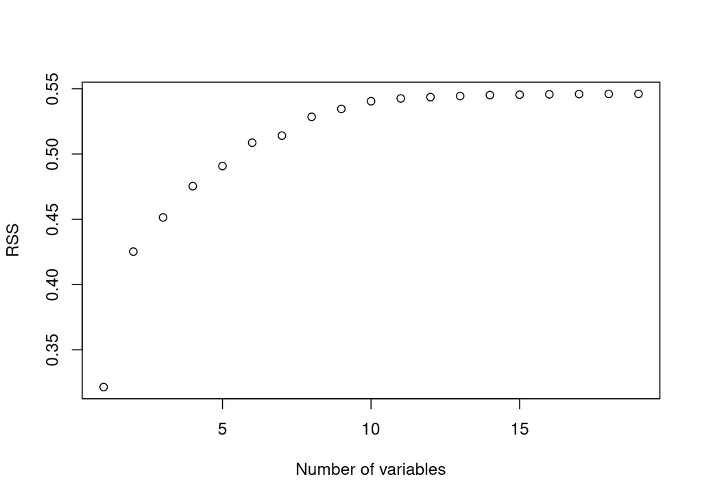

```r
plot(summary(subset_fit_full)$rsq, xlab = "Number of variables",
     ylab = "RSS")
```

### Plotting the Adjusted “R(2)”:

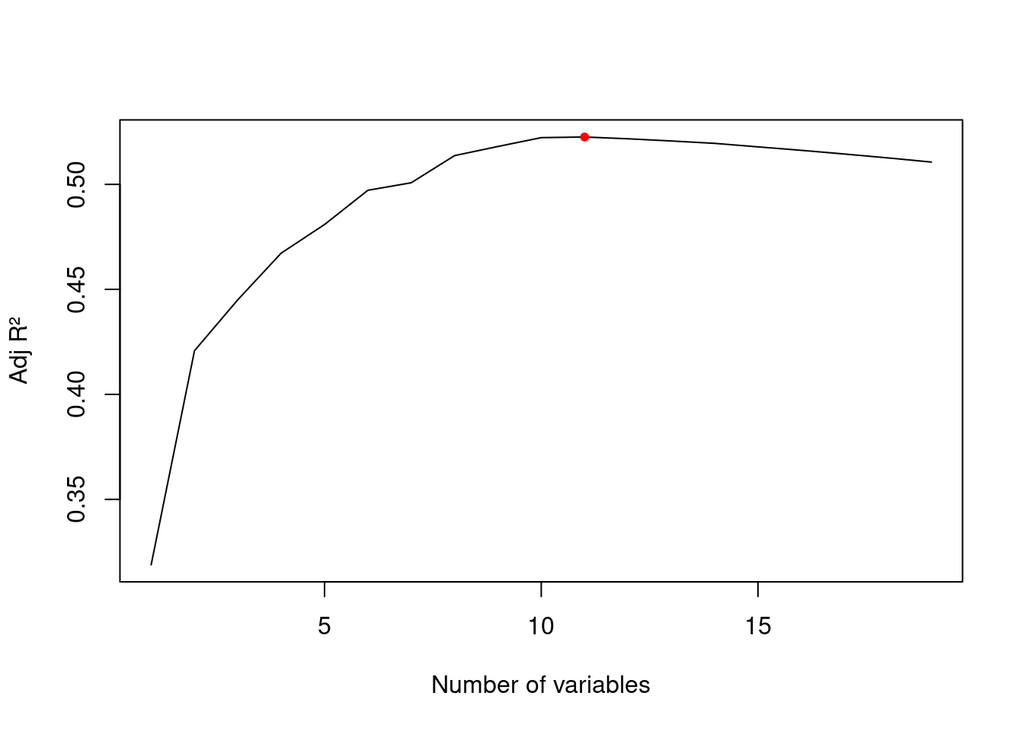

```r
plot(summary(subset_fit_full)$adjr2, xlab = "Number of variables",
     ylab = "Adj R²", type = "l")

points(11, summary(subset_fit_full)$adjr2[11], col = "red", pch = 20)
```

### Plotting the “Cp” Metric:

```r
plot(summary(subset_fit_full)$cp, xlab = "Number of Variables", ylab = "Cp",
     type = "l")
which.min(summary(subset_fit_full)$cp)
```

```
## [1] 10
```

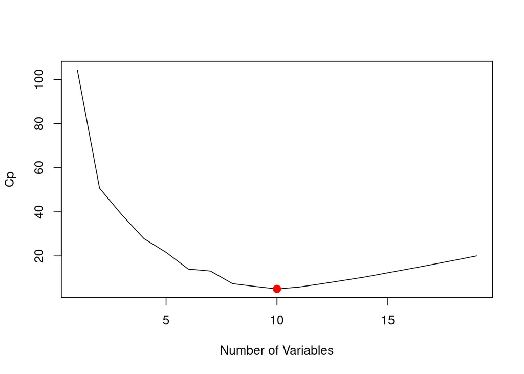

```r
points(10, summary(subset_fit_full)$cp[10], col = "red", cex = 2, pch = 20)
```

### Plotting the BIC Metric:

```r
which.min(summary(subset_fit_full)$bic)
```

```
## [1] 6
```

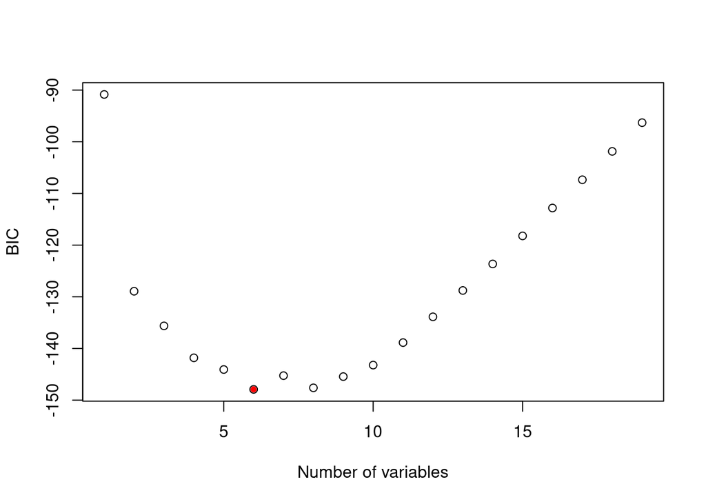

```r
plot(summary(subset_fit_full)$bic, xlab = "Number of variables",
     ylab = "BIC")
points(6, summary(subset_fit_full)$bic[6], col = "red", pch = 20)
```

### The top row of each plot contains a black square for each variable selected

According to the optimal model associated with that statistic. For instance, we see that several models share a BIC close to −150. However, the model with the lowest BIC is the six-variable model that contains only AtBat, Hits, Walks, CRBI, DivisionW, and PutOuts. We can use the coef() function to see the coefficient estimates associated with this model.

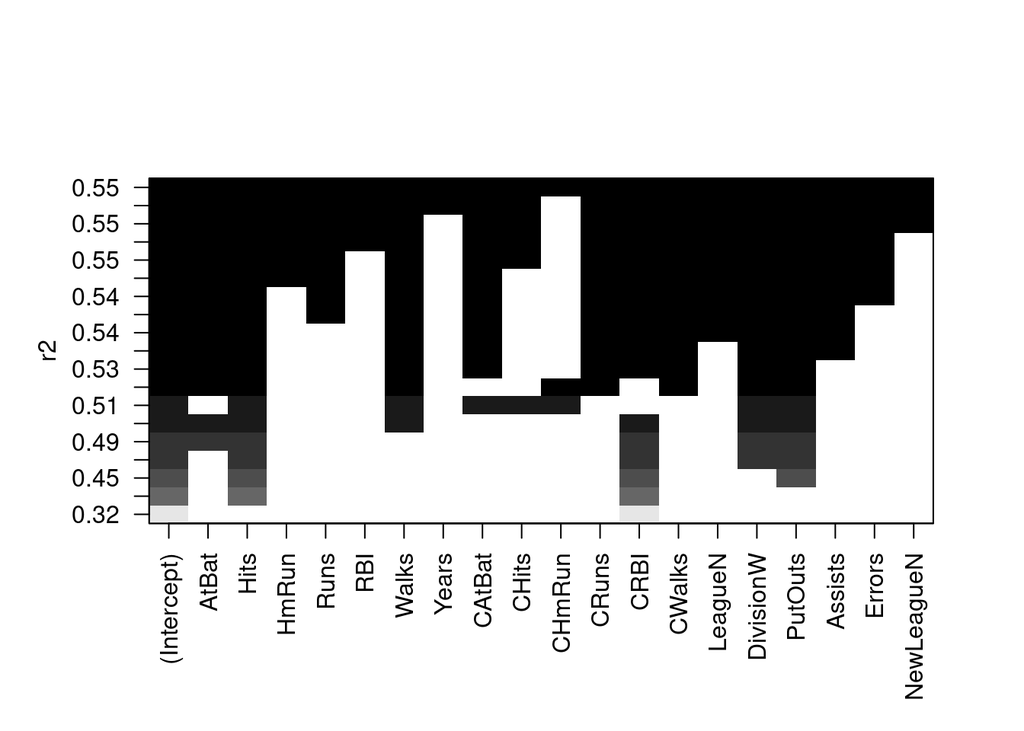

```r
plot(subset_fit_full, scale = "r2")
```

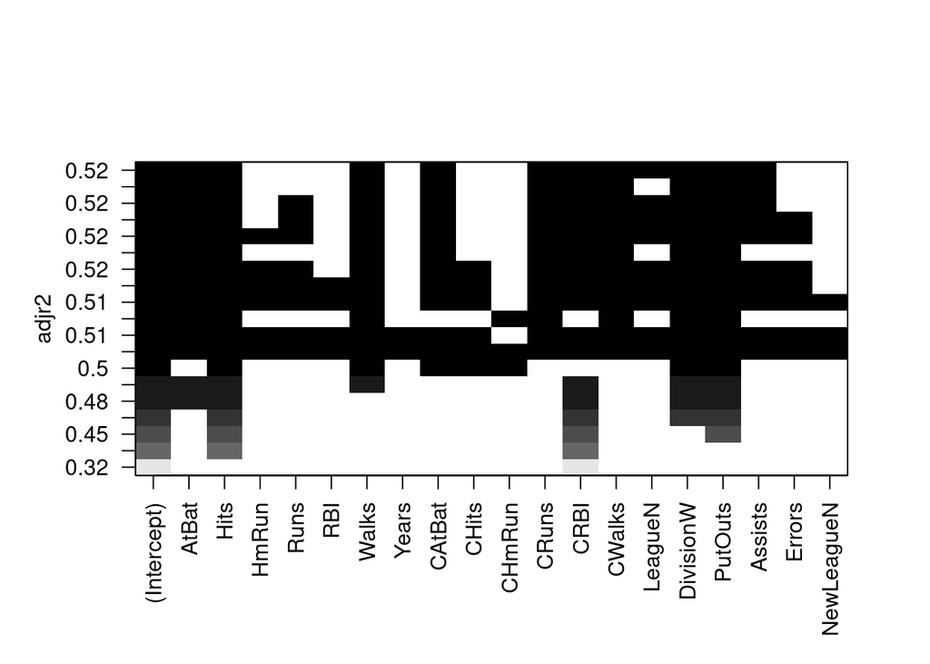

```r
plot(subset_fit_full, scale = "adjr2")
```

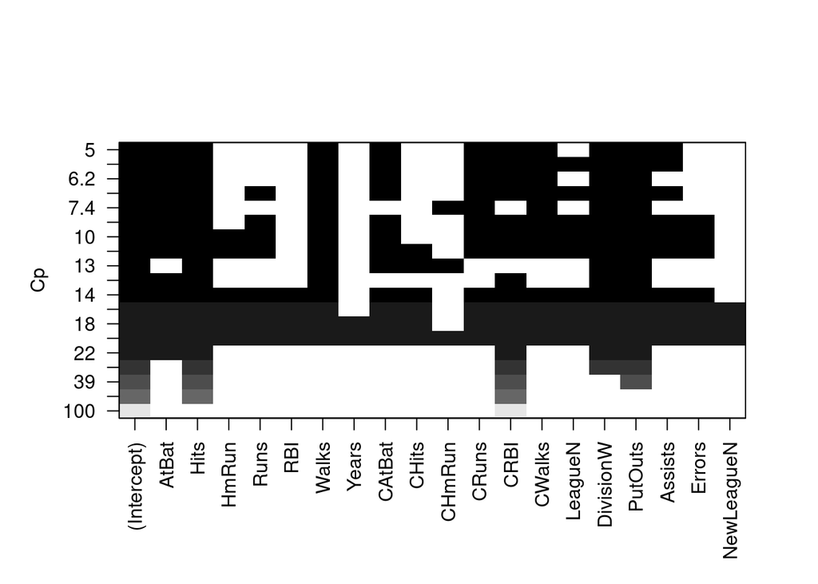

```r
plot(subset_fit_full, scale = "Cp")
```

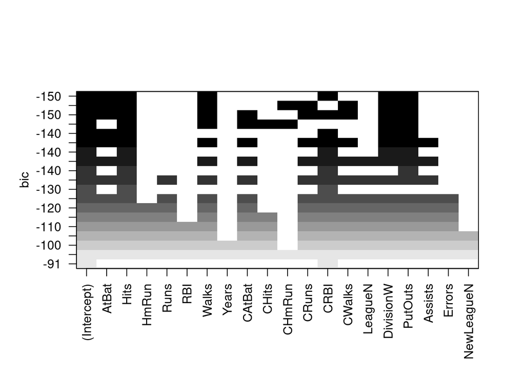

```r
plot(subset_fit_full, scale = "bic")
```

```r
coef(subset_fit_full, 6)
```

```
##  (Intercept)        AtBat         Hits        Walks         CRBI    DivisionW
##   91.5117981   -1.8685892    7.6043976    3.6976468    0.6430169 -122.9515338
##      PutOuts
##    0.2643076
```

### Forward and Backward Step wise Selection

```r
fit_forward <- regsubsets(Salary~., data = Hitters, nvmax = 19, method = "forward")
summary(fit_forward)
```

```
## Subset selection object
## Call: regsubsets.formula(Salary ~ ., data = Hitters, nvmax = 19, method = "forward")
## 19 Variables  (and intercept)
##            Forced in Forced out
## AtBat          FALSE      FALSE
## Hits           FALSE      FALSE
## HmRun          FALSE      FALSE
## Runs           FALSE      FALSE
## RBI            FALSE      FALSE
## Walks          FALSE      FALSE
## Years          FALSE      FALSE
## CAtBat         FALSE      FALSE
## CHits          FALSE      FALSE
## CHmRun         FALSE      FALSE
## CRuns          FALSE      FALSE
## CRBI           FALSE      FALSE
## CWalks         FALSE      FALSE
## LeagueN        FALSE      FALSE
## DivisionW      FALSE      FALSE
## PutOuts        FALSE      FALSE
## Assists        FALSE      FALSE
## Errors         FALSE      FALSE
## NewLeagueN     FALSE      FALSE
## 1 subsets of each size up to 19
## Selection Algorithm: forward
##           AtBat Hits HmRun Runs RBI Walks Years CAtBat CHits CHmRun CRuns CRBI
## 1  ( 1 )  " "   " "  " "   " "  " " " "   " "   " "    " "   " "    " "   "*"
## 2  ( 1 )  " "   "*"  " "   " "  " " " "   " "   " "    " "   " "    " "   "*"
## 3  ( 1 )  " "   "*"  " "   " "  " " " "   " "   " "    " "   " "    " "   "*"
## 4  ( 1 )  " "   "*"  " "   " "  " " " "   " "   " "    " "   " "    " "   "*"
## 5  ( 1 )  "*"   "*"  " "   " "  " " " "   " "   " "    " "   " "    " "   "*"
## 6  ( 1 )  "*"   "*"  " "   " "  " " "*"   " "   " "    " "   " "    " "   "*"
## 7  ( 1 )  "*"   "*"  " "   " "  " " "*"   " "   " "    " "   " "    " "   "*"
## 8  ( 1 )  "*"   "*"  " "   " "  " " "*"   " "   " "    " "   " "    "*"   "*"
## 9  ( 1 )  "*"   "*"  " "   " "  " " "*"   " "   "*"    " "   " "    "*"   "*"
## 10  ( 1 ) "*"   "*"  " "   " "  " " "*"   " "   "*"    " "   " "    "*"   "*"
## 11  ( 1 ) "*"   "*"  " "   " "  " " "*"   " "   "*"    " "   " "    "*"   "*"
## 12  ( 1 ) "*"   "*"  " "   "*"  " " "*"   " "   "*"    " "   " "    "*"   "*"
## 13  ( 1 ) "*"   "*"  " "   "*"  " " "*"   " "   "*"    " "   " "    "*"   "*"
## 14  ( 1 ) "*"   "*"  "*"   "*"  " " "*"   " "   "*"    " "   " "    "*"   "*"
```

[output cut: 10 more lines]

```
## 5  ( 1 )  " "    " "     "*"       "*"     " "     " "    " "
## 6  ( 1 )  " "    " "     "*"       "*"     " "     " "    " "
## 7  ( 1 )  "*"    " "     "*"       "*"     " "     " "    " "
## 8  ( 1 )  "*"    " "     "*"       "*"     " "     " "    " "
## 9  ( 1 )  "*"    " "     "*"       "*"     " "     " "    " "
## 10  ( 1 ) "*"    " "     "*"       "*"     "*"     " "    " "
## 11  ( 1 ) "*"    "*"     "*"       "*"     "*"     " "    " "
## 12  ( 1 ) "*"    "*"     "*"       "*"     "*"     " "    " "
## 13  ( 1 ) "*"    "*"     "*"       "*"     "*"     "*"    " "
## 14  ( 1 ) "*"    "*"     "*"       "*"     "*"     "*"    " "
## 15  ( 1 ) "*"    "*"     "*"       "*"     "*"     "*"    " "
## 16  ( 1 ) "*"    "*"     "*"       "*"     "*"     "*"    " "
## 17  ( 1 ) "*"    "*"     "*"       "*"     "*"     "*"    "*"
## 18  ( 1 ) "*"    "*"     "*"       "*"     "*"     "*"    "*"
## 19  ( 1 ) "*"    "*"     "*"       "*"     "*"     "*"    "*"
```

```r
fit_backward <- regsubsets(Salary~., data = Hitters, nvmax = 19, method = "backward")
```

```r
print("Best subset 7")
```

```
## [1] "Best subset 7"
```

```r
coef(subset_fit_full, 7)
```

```
##  (Intercept)         Hits        Walks       CAtBat        CHits       CHmRun
##   79.4509472    1.2833513    3.2274264   -0.3752350    1.4957073    1.4420538
##    DivisionW      PutOuts
## -129.9866432    0.2366813
```

```r
print("Best foward")
```

```
## [1] "Best foward"
```

```r
coef(fit_forward, 7)
```

```
##  (Intercept)        AtBat         Hits        Walks         CRBI       CWalks
##  109.7873062   -1.9588851    7.4498772    4.9131401    0.8537622   -0.3053070
##    DivisionW      PutOuts
## -127.1223928    0.2533404
```

```r
print("Best backward")
```

```
## [1] "Best backward"
```

```r
coef(fit_backward, 7)
```

```
##  (Intercept)        AtBat         Hits        Walks        CRuns       CWalks
##  105.6487488   -1.9762838    6.7574914    6.0558691    1.1293095   -0.7163346
##    DivisionW      PutOuts
## -116.1692169    0.3028847
```

In order to use the validation set approach, we begin by splitting the observations into a training set and a test set. We do this by creating a random vector, train, of elements equal to TRUE if the corresponding observation is in the training set, and FALSE otherwise. The vector test has a TRUE if the observation is in the test set, and a FALSE otherwise. Note the ! in the command to create test causes TRUE to be switched to FALSE and viceversa. We also set a random seed so that the user will obtain the same training set/test set split.

```r
set.seed(1)
train <- sample(c(TRUE, FALSE), nrow(Hitters), replace = TRUE)
test <- (!train)
```

We fit the model and predict

```r
regfit_best <- regsubsets(Salary~., data = Hitters[train,],
                          nvmax = 19)
test.mat <- model.matrix(Salary~., data = Hitters[test,])
```

We use a for to calculate the errors between each best subset model:

```r
val.errors <- rep (NA, 19)

for (i in 1:19) {
  coefi <- coef(regfit_best, id = i)
  pred <- test.mat[, names(coefi)] %*% coefi
  val.errors[i] <- mean((Hitters$Salary[test] - pred)^2)

}
```

```r
which.min (val.errors)
```

```
## [1] 7
```

The best model (using the minimum value errors) contains 7 variables and the coefficients to each variable are depicted below:

```r
coef(regfit_best, 7)
```

```
##  (Intercept)        AtBat         Hits        Walks        CRuns       CWalks
##   67.1085369   -2.1462987    7.0149547    8.0716640    1.2425113   -0.8337844
##    DivisionW      PutOuts
## -118.4364998    0.2526925
```

This is a function that mimics the `predict` function built-in. We are going to call it `predicti_regsubsets`

```r
predict_regsubsets <- function(object, newdata, id, ...){
  form <- as.formula(object$call[[2]])
  mat <- model.matrix(form, newdata)
  coefi <- coef(object, id = id)
  xvars <- names(coefi)
  mat[, xvars] %*% coefi
}
```

Now we do the folds manually (k = 10 folds) using the sample method.

```r
k <- 10
n <- nrow(Hitters)
set.seed(1)

folds <- sample(rep(1:k, length = n))
```

Now we write a for **loop** that performs `cross-validation`. In the **jth fold**, the elements of folds **that equal j are in the test set**, and the remainder are in the training set. We make our predictions for each model size (using our new predict method(`predicti_regsubsets`), compute the test errors on the appropriate subset, and store them in the appropriate slot in the matrix cv.errors.

```r
# creating an empty matrix/dataframe to store our cross-validation values
cv.errors <- matrix(NA, k, 19, dimnames = list(NULL, paste(1:19)))


for (j in 1:k) {

  best.fit <- regsubsets(Salary~., data = Hitters[folds != j,],
                         nvmax = 19)
  for (i in 1:19) {
    pred <- predict_regsubsets(best.fit , Hitters[folds == j,], id = i)
    cv.errors[j, i] <- mean((Hitters$Salary[folds == j] - pred)^2)
  }
}
```

```r
cv.errors
```

```
##              1         2         3         4         5         6         7
##  [1,] 127890.3 125463.90 128578.79 111911.33 101114.60  95242.33  98345.63
##  [2,] 168327.4 210821.67 184753.93 231804.36 224179.03 210352.40 211473.31
##  [3,] 132686.8  84650.97  86454.94  78680.10  96050.17  84208.72  95356.47
##  [4,] 157239.1 106906.32 102772.55  89610.47  94583.00  92662.53  92414.38
##  [5,] 201947.5 236203.66 241277.30 228782.15 242071.17 231501.14 234597.48
##  [6,] 105885.2 105126.11 105652.01 115548.80 104185.91  83944.52  91226.14
##  [7,] 120544.8  79228.77 162416.06 168996.23 157271.42 131733.84 132134.43
##  [8,] 158274.6 127558.76 120573.89 106130.02  99976.67  88645.76  90748.45
##  [9,] 158893.7 124649.66 120495.75 102801.28  96954.11 107281.30  96263.87
## [10,] 102708.6  67560.46  89166.47  83564.71  91269.99  78256.69  71870.79
##               8         9        10        11        12        13        14
##  [1,]  84814.23  83455.36  75726.63  78463.82  79888.20  82484.65  80951.81
##  [2,] 197304.23 200266.64 187609.44 201795.83 200380.62 198914.41 199402.06
##  [3,]  85614.74  79881.26  81255.69  90018.75  89450.30  91886.23  92501.70
```

[output cut: 18 more lines]

This has given us a **10×19 matrix**, of which the (j, i)th element corresponds to the test **MSE** for the **jth cross-validation fold** for the **best i-variable model**. We use the apply() function **to average over the columns of this** `apply()` matrix in order to obtain a vector for which the ith element is the cross- validation error for the i-variable model.

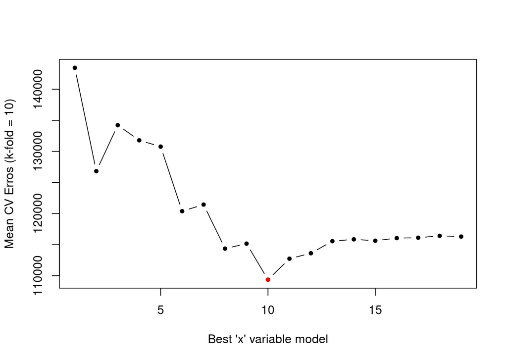

```r
mean.cv.errors <- apply(cv.errors, 2, mean)
plot(mean.cv.errors, type = "b", pch = 20,
     ylab = "Mean CV Erros (k-fold = 10)", xlab = "Best 'x' variable model")
points(10, mean.cv.errors[10], col= "red", pch = 20)
```

We then perform the best subset selection between 1-19 variables on the **FULL DATASET**.

```r
# We build the best subset variable selection searching through 1 to 19 variables
reg_best <- regsubsets(Salary~., data = Hitters, nvmax = 19)

# Selecting the best coeficients
coef(reg_best, 10)
```

```
##  (Intercept)        AtBat         Hits        Walks       CAtBat        CRuns
##  162.5354420   -2.1686501    6.9180175    5.7732246   -0.1300798    1.4082490
##         CRBI       CWalks    DivisionW      PutOuts      Assists
##    0.7743122   -0.8308264 -112.3800575    0.2973726    0.2831680
```

And now we have our best coefficients (best subset selection with i = 10 variables) and that can be used to make new predictions with more reliability.

# Ridge and Lasso Regression

We will use the glmnet package in order to perform ridge regression and the lasso. The main function is `glmnet()`, which can be use to fit a variety of regression models. This function has a different syntax: we must pass an X matrix and an Y vector of prediction values (not the Y~X syntax).

```r
x <- model.matrix(Salary ~., Hitters)[, -1]
y <- Hitters$Salary
```

`model.matrix()`function is very useful since automatically transforms **any qualitative variables into dummy variables.** Also, `glmnet()` can only take numerical quantitative inputs.

```r
# Checking any NA Values

print("Y VECTOR")
```

```
## [1] "Y VECTOR"
```

```r
print("--------")
```

```
## [1] "--------"
```

```r
print(sum(is.na(Hitters$Salary)))
```

```
## [1] 0
```

```r
print("X MATRIX")
```

```
## [1] "X MATRIX"
```

```r
print("--------")
```

```
## [1] "--------"
```

```r
print(sum(is.na(x)))
```

```
## [1] 0
```

The `glmnet()` function has an alpha argument, if alpha =0 it performs ridge, if alpha = 1 a lasso model is fit.

```r
library(glmnet)
grid <- 10^seq(10, -2, length = 100)

ridge_mod <- glmnet(x, y, alpha = 0, lambda = grid)
```

Note that by default, the `glmnet()` function standardizes the variables so that they are on the same scale. To turn off this default setting, use the argument *standardize = FALSE*.

Associated with each lambda value is 20 coefficients so `coef(ridge_mod)` is a matrix with 20 rows by 100 columns (each column associated with one lambda).

```r
dim(coef(ridge_mod))
```

```
## [1]  20 100
```

The coefficients are going to be much smaller when a large value of lambda is used. When lambda >11000 we have the sum of the square of coef:

```r
cat("current lambda value is:", ridge_mod$lambda[50],"\n")
```

```
## current lambda value is: 11497.57
```

```r
cat("the square root of sum of coefficients squares is: ",
    sqrt(sum(coef(ridge_mod)[-1, 50]^2)))
```

```
## the square root of sum of coefficients squares is:  6.360612
```

On the other hand, when lambda is 705:

```r
cat("current lambda value is: ", ridge_mod$lambda[60], "\n")
```

```
## current lambda value is:  705.4802
```

```r
cat("the square root of sum of coefficients squares is: ",
    sqrt(sum(coef(ridge_mod)[-1,60]^2)))
```

```
## the square root of sum of coefficients squares is:  57.11001
```

Checking the coefficients when lambda = 705:

```r
coef(ridge_mod)[, 60]
```

```
##  (Intercept)        AtBat         Hits        HmRun         Runs          RBI
##  54.32519950   0.11211115   0.65622409   1.17980910   0.93769713   0.84718546
##        Walks        Years       CAtBat        CHits       CHmRun        CRuns
##   1.31987948   2.59640425   0.01083413   0.04674557   0.33777318   0.09355528
##         CRBI       CWalks      LeagueN    DivisionW      PutOuts      Assists
##   0.09780402   0.07189612  13.68370191 -54.65877750   0.11852289   0.01606037
##       Errors   NewLeagueN
##  -0.70358655   8.61181213
```

We can use predict function to predict new coefficients, for example when lambda = 50:

```r
predict(ridge_mod, s = 50, type = "coefficients")[1:20,]
```

```
##   (Intercept)         AtBat          Hits         HmRun          Runs
##  4.876610e+01 -3.580999e-01  1.969359e+00 -1.278248e+00  1.145892e+00
##           RBI         Walks         Years        CAtBat         CHits
##  8.038292e-01  2.716186e+00 -6.218319e+00  5.447837e-03  1.064895e-01
##        CHmRun         CRuns          CRBI        CWalks       LeagueN
##  6.244860e-01  2.214985e-01  2.186914e-01 -1.500245e-01  4.592589e+01
##     DivisionW       PutOuts       Assists        Errors    NewLeagueN
## -1.182011e+02  2.502322e-01  1.215665e-01 -3.278600e+00 -9.496680e+00
```

We now split the samples into a training set and a test set in order to estimate the test error of ridge regression and the lasso.

```r
set.seed(1)
train <- sample(1:nrow(x), nrow(x)/2)
test <- (-train)
y.test <- y[test]
cat("length of y[test] :", length(y.test), "\n")
```

```
## length of y[test] : 132
```

```r
cat("length of y: ", length(y))
```

```
## length of y:  263
```

Fitting a ridge regression splitting training and test group:

```r
ridge_mod_train <- glmnet(x[train,], y[train], alpha = 0, lambda = grid,
                          thresh = 1e-12)
ridge_pred <- predict(ridge_mod_train, s = 4, newx = x[test, ])

mean((ridge_pred - y.test)^2)
```

```
## [1] 142199.2
```

If we simply fit a model with just the intercept we would obtain the MSE of 224.669:

```r
mean((mean(y[train]) - y.test)^2)
```

```
## [1] 224669.9
```

Then, if we fit the same results with a very large value of lambda we would see that the value approaches the MSE using only the mean of y[train] which would be equivalent to fitting the model using just the intercept.

```r
ridge_pred <- predict(ridge_mod_train, s = 1e10, newx = x[test, ])
mean((ridge_pred - y.test)^2)
```

```
## [1] 224669.8
```

If we want to mimic the output by using just the least squares we would do:

```r
ridge_pred <- predict(ridge_mod_train, s = 0, newx = x[test, ], exact = T,
                      x = x[train, ], y = y[train])
mean((ridge_pred - y.test)^2)
```

```
## [1] 168588.6
```

In general, we would rather use the `lm()` function rather than the ridge with 0 penalty.

Now we perform the cross validation approach of ridge regression using the built-in function `cv.glmnet()`. The function performs ten fold (k = 10) by default.

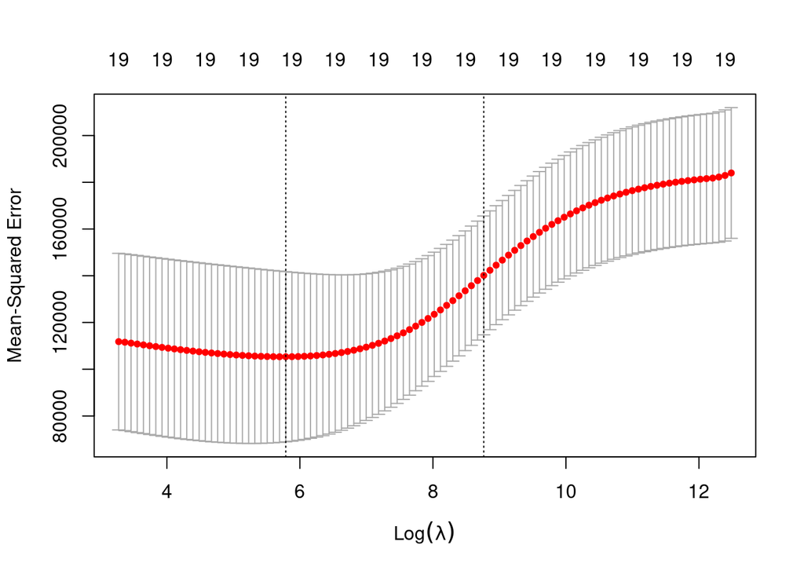

```r
set.seed(1)
cv.out <- cv.glmnet(x[train, ], y[train], alpha  = 0)
plot(cv.out)
```

```r
# We select the best_lambda by using the lambda.min output of the function
best_lambda  = cv.out$lambda.min
cat("The best lambda is: ", best_lambda)
```

```
## The best lambda is:  326.0828
```

What would the MSE of the test would be if the we did the best lambda fitted by cross validation:

```r
# fitting using the best lambda found by cross-validation
ridge_pred <- predict(ridge_mod_train, s = best_lambda, newx = x[test, ])

# then doing the MSE
cat(mean((ridge_pred - y.test)^2), "is the MSE of the test group using lambda: ",
    best_lambda)
```

```
## 139856.6 is the MSE of the test group using lambda:  326.0828
```

Now we finally fit the model using ALL of the dataset:

```r
final_model <- glmnet(x, y, alpha = 0)

coefficients_final <- predict(final_model, type = "coefficients", s = best_lambda)
((as.matrix(coefficients_final)))
```

```
##                       s1
## (Intercept)  15.44383120
## AtBat         0.07715547
## Hits          0.85911582
## HmRun         0.60103106
## Runs          1.06369007
## RBI           0.87936105
## Walks         1.62444617
## Years         1.35254778
## CAtBat        0.01134999
## CHits         0.05746654
## CHmRun        0.40680157
## CRuns         0.11456224
## CRBI          0.12116504
## CWalks        0.05299202
## LeagueN      22.09143197
## DivisionW   -79.04032656
## PutOuts       0.16619903
## Assists       0.02941950
## Errors       -1.36092945
## NewLeagueN    9.12487765
```

# The Lasso

Just like before, we will be using the `glmnet()` function but the alpha would be equal to 1.

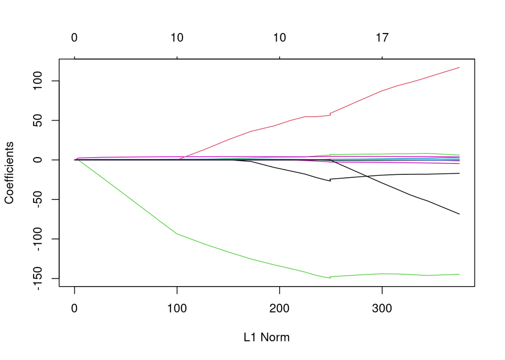

```r
lasso_model <- glmnet(x[train,], y[train], alpha = 1, lambda = grid)
plot(lasso_model)
```

Depending on the L1 norm value, we would see that some coefficients would be exactly 0.

We now perform the cross-validation approach of the LASSO model:

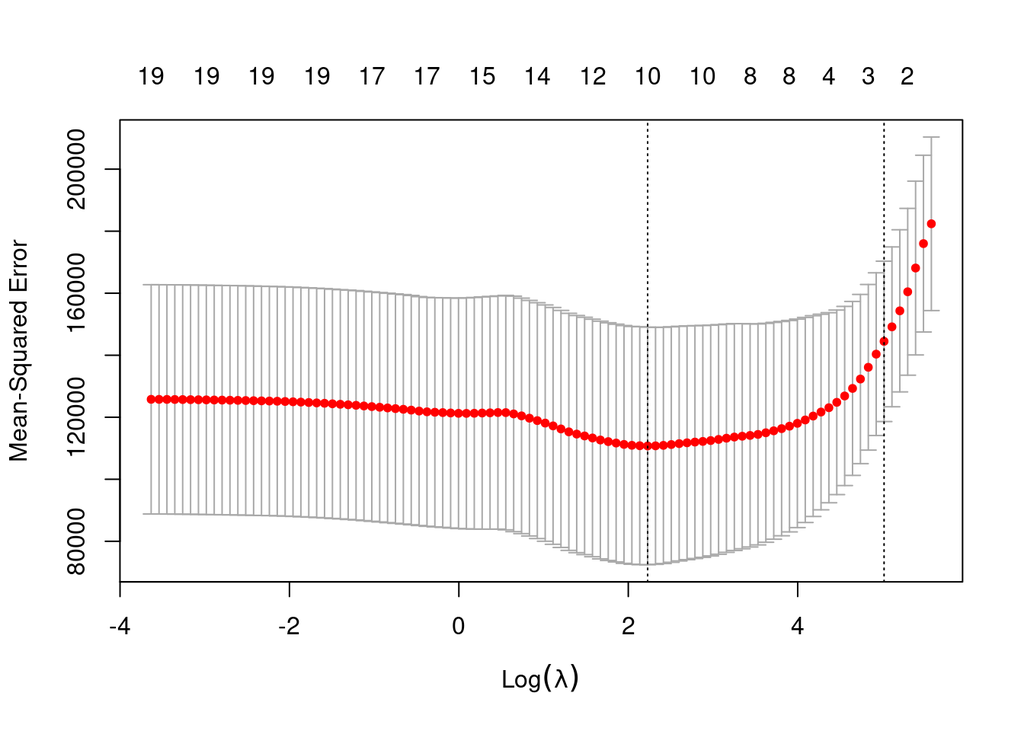

```r
set.seed(1)
lasso_cv <- cv.glmnet(x[train, ], y[train], alpha =1)
plot(lasso_cv)
```

```r
best_lasso_lambda = lasso_cv$lambda.min
cat("The best lasso's lambda using cross validation of the training group is: ",
    best_lasso_lambda)
```

```
## The best lasso's lambda using cross validation of the training group is:  9.286955
```

Now we predict the test set using the best parameter:

```r
set.seed(1)

lasso_pred <- predict(lasso_model, s = best_lasso_lambda, newx = x[test, ])

# Calculating the Mean Square Error of the Best Lasso Model fitted by cross-validation:

mean(((lasso_pred - y.test)^2))
```

```
## [1] 143673.6
```

Now we fit the entire dataset using the best lasso lambda:

```r
lasso_final <- glmnet(x, y, alpha  = 1, lambda = grid)

lass.coef <- predict(lasso_final, type = "coefficients", s = best_lasso_lambda)
as.matrix(lass.coef)
```

```
##                        s1
## (Intercept)    1.27479059
## AtBat         -0.05497143
## Hits           2.18034583
## HmRun          0.00000000
## Runs           0.00000000
## RBI            0.00000000
## Walks          2.29192406
## Years         -0.33806109
## CAtBat         0.00000000
## CHits          0.00000000
## CHmRun         0.02825013
## CRuns          0.21628385
## CRBI           0.41712537
## CWalks         0.00000000
## LeagueN       20.28615023
## DivisionW   -116.16755870
## PutOuts        0.23752385
## Assists        0.00000000
## Errors        -0.85629148
## NewLeagueN     0.00000000
```

# PCR and PLS Regression

```r
library(pls)
set.seed(2)

pcr_fit <- pcr(Salary~., data = Hitters, scale = TRUE, validation = "CV")

summary(pcr_fit)
```

```
## Data:    X dimension: 263 19
##  Y dimension: 263 1
## Fit method: svdpc
## Number of components considered: 19
##
## VALIDATION: RMSEP
## Cross-validated using 10 random segments.
##        (Intercept)  1 comps  2 comps  3 comps  4 comps  5 comps  6 comps
## CV             452    351.9    353.2    355.0    352.8    348.4    343.6
## adjCV          452    351.6    352.7    354.4    352.1    347.6    342.7
##        7 comps  8 comps  9 comps  10 comps  11 comps  12 comps  13 comps
## CV       345.5    347.7    349.6     351.4     352.1     353.5     358.2
## adjCV    344.7    346.7    348.5     350.1     350.7     352.0     356.5
##        14 comps  15 comps  16 comps  17 comps  18 comps  19 comps
## CV        349.7     349.4     339.9     341.6     339.2     339.6
## adjCV     348.0     347.7     338.2     339.7     337.2     337.6
##
## TRAINING: % variance explained
##         1 comps  2 comps  3 comps  4 comps  5 comps  6 comps  7 comps  8 comps
## X         38.31    60.16    70.84    79.03    84.29    88.63    92.26    94.96
## Salary    40.63    41.58    42.17    43.22    44.90    46.48    46.69    46.75
##         9 comps  10 comps  11 comps  12 comps  13 comps  14 comps  15 comps
## X         96.28     97.26     97.98     98.65     99.15     99.47     99.75
## Salary    46.86     47.76     47.82     47.85     48.10     50.40     50.55
##         16 comps  17 comps  18 comps  19 comps
## X          99.89     99.97     99.99    100.00
## Salary     53.01     53.85     54.61     54.61
```

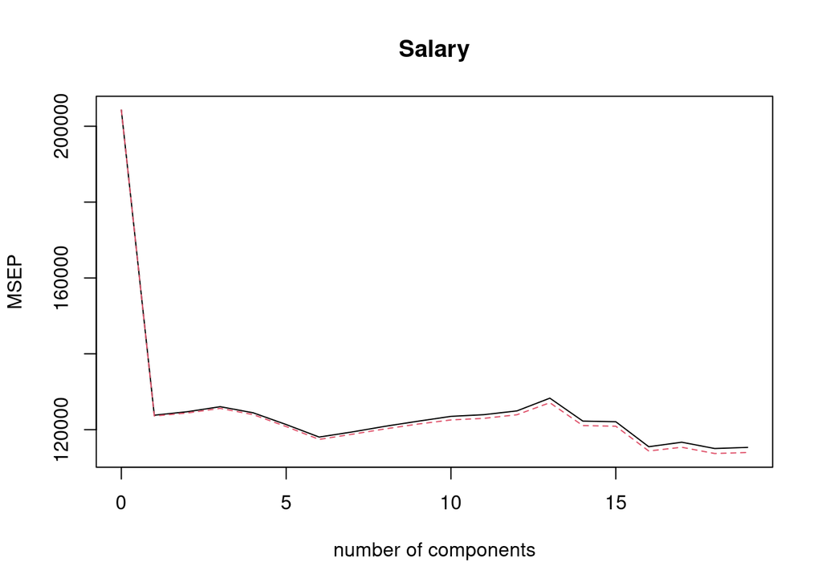

```r
validationplot(pcr_fit, val.type = "MSEP")
```

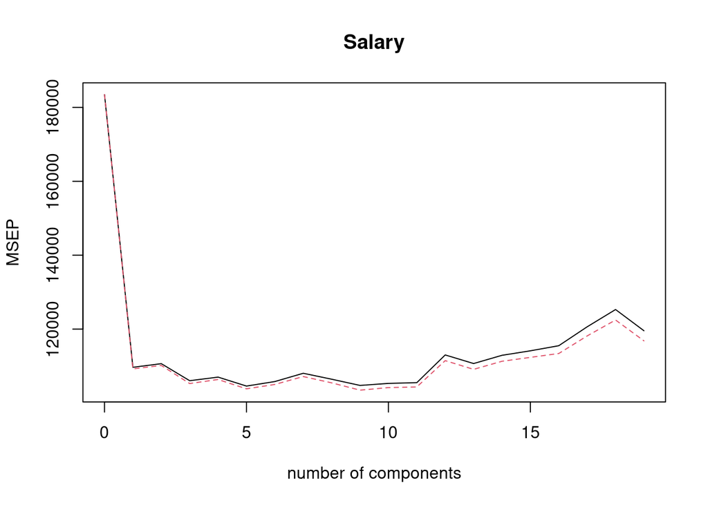

```r
pcr_fit_train <- pcr(Salary~., data = Hitters, subset = train,
                     scale = TRUE, validation = "CV")

validationplot(pcr_fit_train, val.type = "MSEP")
```

```r
#pcr_pred <- predict(pcr_fit, x[test, ], ncomp = 5)
```

```r
pcr_pred <- predict(pcr_fit_train, x[test, ], ncomp = 5)
mean((pcr_pred - y.test)^2)
```

```
## [1] 142811.8
```

### Doing the final model

```r
pcr_fit_final <- pcr(y ~x, scale = TRUE, ncomp = 5)
summary(pcr_fit_final)
```

```
## Data:    X dimension: 263 19
##  Y dimension: 263 1
## Fit method: svdpc
## Number of components considered: 5
## TRAINING: % variance explained
##    1 comps  2 comps  3 comps  4 comps  5 comps
## X    38.31    60.16    70.84    79.03    84.29
## y    40.63    41.58    42.17    43.22    44.90
```

```r
pcr_pred_final <- predict(pcr_fit_final, x, ncomp = 5)
mean((pcr_pred_final - y)^2)
```

```
## [1] 111697.6
```

### Partial Least Squares

We perform partial least squares using the pls library and `plsr()` function.

```r
set.seed(1)
pls_fit <- plsr(Salary~., data = Hitters, subset = train, scale = TRUE, validation = "CV")

summary(pls_fit)
```

```
## Data:    X dimension: 131 19
##  Y dimension: 131 1
## Fit method: kernelpls
## Number of components considered: 19
##
## VALIDATION: RMSEP
## Cross-validated using 10 random segments.
##        (Intercept)  1 comps  2 comps  3 comps  4 comps  5 comps  6 comps
## CV           428.3    325.5    329.9    328.8    339.0    338.9    340.1
## adjCV        428.3    325.0    328.2    327.2    336.6    336.1    336.6
##        7 comps  8 comps  9 comps  10 comps  11 comps  12 comps  13 comps
## CV       339.0    347.1    346.4     343.4     341.5     345.4     356.4
## adjCV    336.2    343.4    342.8     340.2     338.3     341.8     351.1
##        14 comps  15 comps  16 comps  17 comps  18 comps  19 comps
## CV        348.4     349.1     350.0     344.2     344.5     345.0
## adjCV     344.2     345.0     345.9     340.4     340.6     341.1
##
## TRAINING: % variance explained
##         1 comps  2 comps  3 comps  4 comps  5 comps  6 comps  7 comps  8 comps
## X         39.13    48.80    60.09    75.07    78.58    81.12    88.21    90.71
## Salary    46.36    50.72    52.23    53.03    54.07    54.77    55.05    55.66
##         9 comps  10 comps  11 comps  12 comps  13 comps  14 comps  15 comps
## X         93.17     96.05     97.08     97.61     97.97     98.70     99.12
## Salary    55.95     56.12     56.47     56.68     57.37     57.76     58.08
##         16 comps  17 comps  18 comps  19 comps
## X          99.61     99.70     99.95    100.00
## Salary     58.17     58.49     58.56     58.62
```

We now use the built in function`validationplot()`

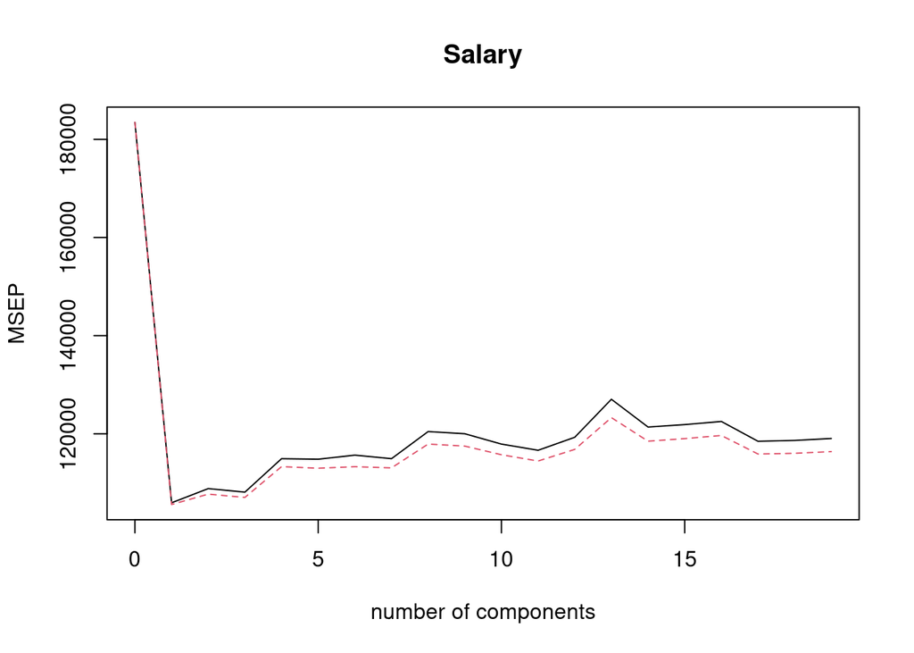

```r
validationplot(pls_fit, val.type = "MSEP")
```

We fit the entire dataset using only one component as we saw it on cross-validation approach.

```r
pls_fit_final <- plsr(Salary~., data = Hitters, scale =TRUE, ncomp =1)
summary(pls_fit_final)
```

```
## Data:    X dimension: 263 19
##  Y dimension: 263 1
## Fit method: kernelpls
## Number of components considered: 1
## TRAINING: % variance explained
##         1 comps
## X         38.08
## Salary    43.05
```

Notice that the percentage of variance in Salary that the one-component PLS fit explains, 43.05 %, is almost as much as that explained using the final five-component model PCR fit, 44.90 %. **This is because PCR only attempts to maximize the amount of variance explained in the predictors, while PLS searches for directions that explain variance in both the predictors and theresponse.**